# Preparação de dados

- Mostrar o código
- Esconder o código
- Ver o código fonte

Aplicações com o pacote geomarkbr

Autor

Gustavo Givisiez

Data de Publicação

5 de maio de 2026

**Código**

```r
library(dplyr)
library(sf)
library(tmap)
library(geomarkbr)
tmap::tmap_mode("plot")
```

# 1 Introdução

O objetivo dessa aula é preparar os dados que serão usados na análise de localização. Não vamos aprender como desenhar mapas: a aula de hoje é sobre construir a base que torna o mapa possível. Para isso ela se distribui em duas seções. A primeira dela é dedicada a importação de dados dos Agregados por Setor Censitário do Censo Demográfico de 2022 do Brasil. Ele usa o pacote `geomarkbr` (Givisiez, 2026) e dois outros pacotes densenvolvidos pelo IPEA que são e o `censobr` (Rafael H. M. Pereira *et al.*, 2023) e o `geobr` (Gonçalves; Pereira; Instituto de Pesquisa Econômica Aplicada (ipea), 2009)

# 2 Censo Demográfico

## 2.1 Baixar dados do Censo

Para baixar as shapes dos setores censitários o comando `gm_read_sectors_shape` busca as shapes no servidor do IPEA. Na sequencia baixamos os dados de São José de Ubá (RJ).

**Código**

```r
gm_read_sectors_shape(code = 3305133) # São José de Ubá (RJ)
```

Entretanto, o download direto dos setores censitários via internet pode apresentar instabilidade, seja por limitações de conexão ou mudanças nos servidores. Para garantir que todos consigam acompanhar a aula sem problemas, utilizaremos uma base local para o Rio de Janeiro previamente baixada pelo pacote `geobr`.

A partir dessa base, iremos **filtrar apenas o município de São João da Barra (código 3305000)**, trabalhando com um conjunto de dados menor e mais adequado para as atividades em sala.

**Código**

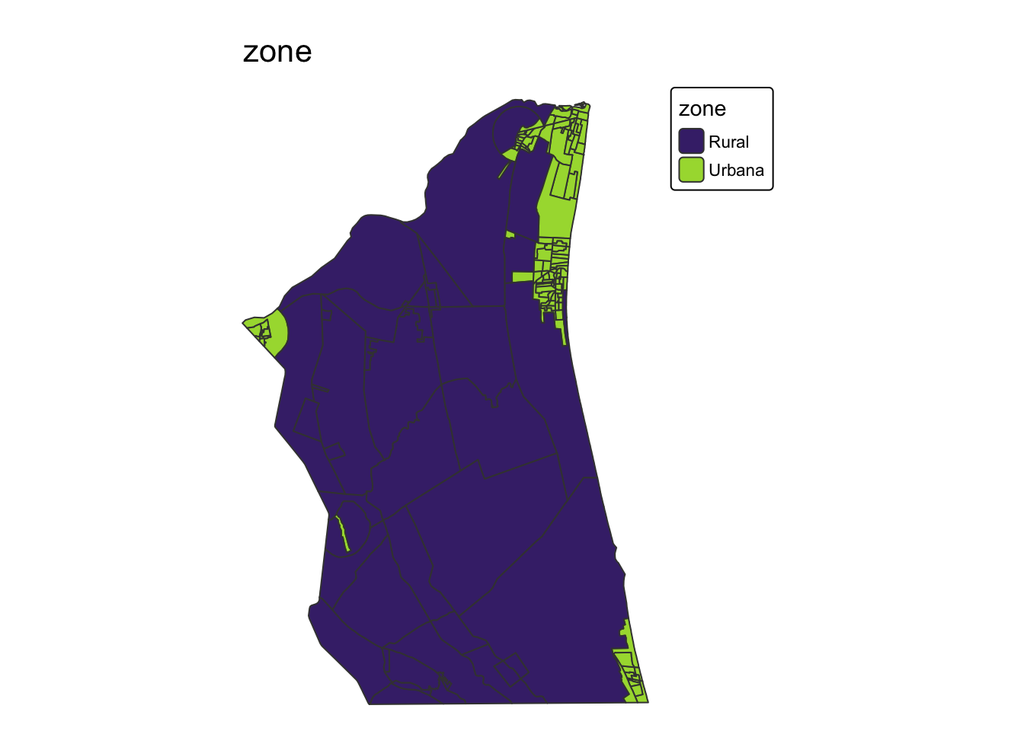

```r
# Base local (RJ inteiro) + filtro para São João da Barra

#dados_pf = "site/tutorials/dados/" #dev
dados_pf = here::here('tutorials/dados/') # render

setores <- gm_read_sectors_shape(
  path = paste0(dados_pf,"shape_rj.gpkg"),
  code = 3305000
)

gm_plot_basic(setores, var = 'zone')
```

**Dica💡 Dica**

Os setores censitários podem ser obtidos diretamente por meio de uma ampla gama de codigos. O argumento `code` da função `gm_read_sectors` segue lógica similar ao pacote `geobr` com algumas variações:

- Se for informado um código de município com 7 dígitos (por exemplo, `3305000`), a função retorna apenas os setores desse município.
- Se for informado um código de estado (por exemplo, `33`) ou a sigla da unidade da federação (por exemplo, `"RJ"`), a função retorna todos os setores daquele estado.
- Se for informado `"all"`, a função retorna os setores de todo o Brasil.
- Há outras formas de baixar dados dos Setores Censitários previstos nessa função (bairro, cidade, regiões intermediárias, etc.). Consulte `?gm_read_sectors` para mais informações

Essa flexibilidade permite trabalhar com diferentes escalas territoriais, desde um único município até o país inteiro.

Para baixar os dados propriamente dito, a função é `gm_read_sectors_data`, como a seguir. No default, a fução baixa o `dataset='Basico'`

Mas, como antes, nem sempre os dados estão disponíveis e por isso vamos usar a base com dados locais para o Rio de Janeiro. Selecionamos apenas o município de São João da Barra

**Código**

```r
# Base local (RJ inteiro) + filtro para São João da Barra
dados_basico <- gm_read_sectors_data(
  path = paste0(dados_pf,"data_basico_rj.rds"),
  code = 3305000
)
```

Lembrem-se que para juntar dados com setores é pelo `gm_join_data`

**Código**

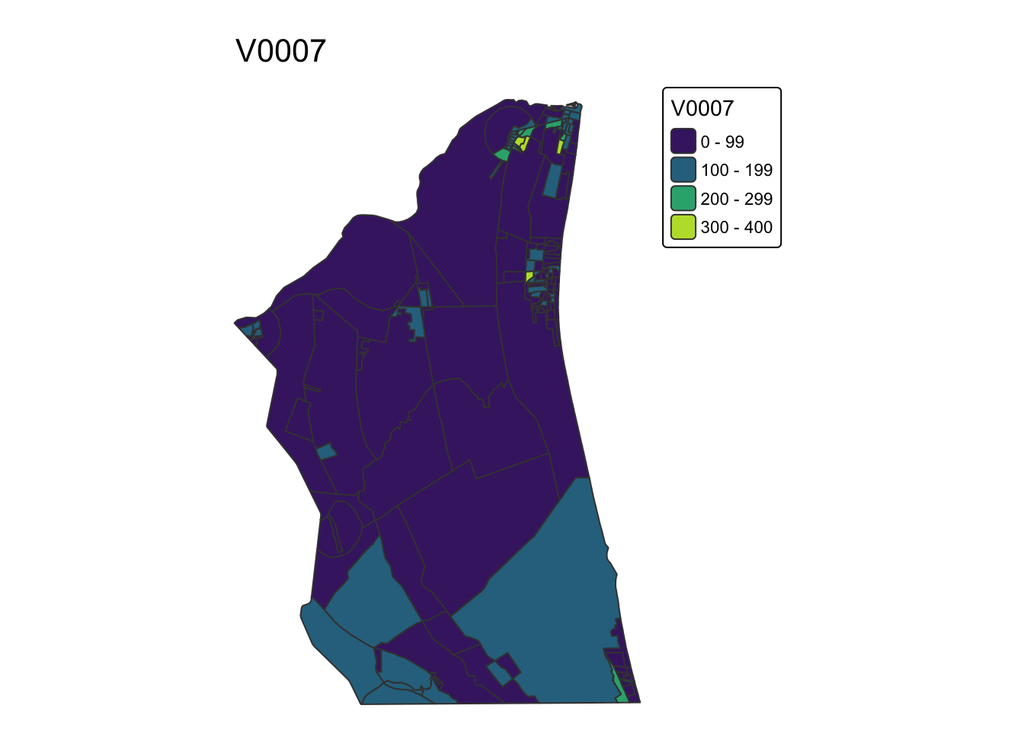

```r
base_basico <- gm_join_data(dados_basico, setores)

gm_plot_basic(base_basico, var = 'V0007')
```

## 2.2 Entendendo o dicionário do censo

Há infinitas bases de dados no Brasil e no munndo. Mas, elas são ilegíveis e inúteis sem o dicionário, que deve sempre (ou quase sempre) acompanhar as bases de dados. Essa seção se dedica a entender o dicionário e, por meio dele, selecionar as variáveis que nos interessam. O dicionário dos setores censitários são disponibilizados pelo `censobr::data_dictionary(year = 2022, dataset = "tracts")` e já estão salvos na estrutura do pacote.

O comando a seguir acha esse dicionário e abre o Excel.

**Código**

```r
file <- gm_example_data_path("2022_dictionary_tracts.xlsx")
utils::browseURL(file)
```

O arquivo Excel do dicionário é organizado em planilhas, cada uma correspondente a um dos conjuntos de dados disponíveis (`dataset`) no `censobr::read_tracts()`, além de planilhas auxiliares com informações complementares. A planilha **Siglas_Basico** apresenta o dicionário das siglas utilizadas nas variáveis V0001 a V0007 do conjunto `dataset = "Basico"`. As demais planilhas correspondem aos principais conjuntos temáticos de variáveis: **Basico**, **Pessoas**, **Domicilios**, **Obitos**, **Indigenas**, **Quilombolas**, **ResponsavelRenda** e **Entorno**. Cada uma dessas planilhas descreve as variáveis disponíveis em seu respectivo dataset, permitindo identificar seus códigos, descrições e formas de uso na análise dos dados censitários.

## 2.3 Selecionar variáveis

A partir desse ponto, começa o trabalho “real” de selecionar as variáveis que nos interessam no banco de dados. Nesse exemplo vamos filtar a renda média do chefe no setor censitário e calcular a proporção de crianças dentro do setor.

**Dica💡 Dica**

Lembrem-se que podemos filtrar desde já quais *territórios* vamos trabalhar. No exemplo abaixo filtramos os dados sobre a renda do chefe e dados demográficos para o município de São João da Barra.

**Código**

```r
dados_pessoas <- gm_read_sectors_data(code = 3305000,
                                      path = paste0(dados_pf,"data_pessoas_rj.rds"),
                                      dataset = "Pessoas")

dados_responsavelrenda <- gm_read_sectors_data(code = 3305000,
                                               path = paste0(dados_pf,"data_responsavelrenda_rj.rds"),
                                               dataset = "ResponsavelRenda")
```

### 2.3.1 Renomear variáveis e limpar o banco

Dois problemas surgem quando estamos trabalhando com grandes bases de dados. Sao muitas variáveis: o banco de dados depessoas tem 724 variáveis e o da renda é até menorzinho com 54 colunas. A primeira tarefa é deixar na base apenas as vaiáveis que nos interessam.

Para a renda dos setores censitários temos duas medidas de tendência central: - **V06004**: Rendimento nominal (em reais em 01/08/2022) médio dos responsáveis com rendimentos (DPP ocupados) - **V06005**: Variância do rendimento mensal dos responsáveis com rendimentos (DPP ocupados)

Para a proporção de crianças: - **demografia_V01006**: Quantidade de moradores - **demografia_V01031**: Quantidade de moradores de 0 a 4 anos - **demografia_V01032**: Quantidade de moradores de 5 a 9 anos - **demografia_V01033**: Quantidade de moradores de 10 a 14 anos

Precisamos ainda deixar nas tabelas de dados a variável `code_tract` que identifica o setor censitário e é a chave de união das tabelas.

Sem esssa seleção prévia, o código e as nases de dados ficam muito mais difíceis de entender. Antes de criar mapas ou calcular indicadores, precisamos organizar a base de dados. Essa etapa é importante porque as bases originais do Censo têm muitas variáveis, com nomes pouco intuitivos. Por isso, vamos usar o pacote `dplyr` (Wickham *et al.*, 2014), que é uma biblioteca que faz parte da coleção `tidyverse` [wickham2019b], para selecionar apenas as colunas necessárias e renomeá-las de forma mais clara.

A ideia não é decorar todos os comandos, mas entender o fluxo. Assim, os passos quase sempre serão:

1. `Selecionar` colunas e `Filtar` o conjunto de dados
2. `Renomear` colunas
3. `Calcular` indicadores
4. `Salvar` a base processada

As três primeiras etapas podem ser encadeadas em uma sequência de pipes (`%>%`), como no codigo a seguir. Após o processamento, é uma boa prática salvar a base já organizada. Isso evita repetir todas as etapas de preparação sempre que o projeto for aberto novamente.

**Código**

```r
dados_responsavelrenda_clean = dados_responsavelrenda %>%
  select(code_tract, V06004, V06005) %>%
  rename(renda_media = V06004,
         renda_var = V06005)

readr::write_rds(
  dados_responsavelrenda_clean,
  "dados/dados_responsavelrenda_clean.rds"
)

dados_pessoas_clean = dados_pessoas %>%
  select(code_tract, demografia_V01006, demografia_V01031, demografia_V01032, demografia_V01033) %>%
  rename(pop = demografia_V01006,
         pop_abs_00_04 = demografia_V01031,
         pop_abs_05_09 = demografia_V01032,
         pop_abs_10_14 = demografia_V01033) %>%
  mutate(
    pop_criancas =
      coalesce(pop_abs_00_04, 0) +
      coalesce(pop_abs_05_09, 0) +
      coalesce(pop_abs_10_14, 0),
  perc_criancas = pop_criancas/pop)
base_basico <- gm_join_data(setores, dados_basico)

readr::write_rds(
  dados_pessoas_clean,
  "dados/dados_pessoas_clean.rds"
)
```

**NotaPara saber mais**

O pacote `dplyr` é um pacote construído para manipulação de dados e usa tipo de gramática para isso. Essa gramática prevê um conjunto de funções (*verbos*) consistentes para ajudar a resolver os principais desafios da manipulação de base de dados. A sintaxe dessa gramática é `x %>% função` onde o `x` seria o dataframe ou a shape (o *sujeito*) e a `função` é um comando do R. O símbolo `%>%` é, por convenção chamado de pipe (conector, em português) que junta um objeto com a função. Escrever o comando `x %>% comando` é o mesmo que escrever `comando(x)` (execute esse comando em x).

**Código**

```r
x<-c(3,6,9,26)
sum(x)
```

```
#> [1] 44
```

```r
## É o mesmo que
x %>% sum()
```

```
#> [1] 44
```

Alguns dos principais comandos do `dplyr` são:

**`select()`**: Seleciona colunas da base de dados. É útil para reduzir o número de variáveis e manter apenas aquelas necessárias para a análise. `select(code_tract, pop, renda_media)` seleciona as variáveis `code_tract`, `pop` e `renda_media`.

**`filter()`**: Filtra linhas da base de dados a partir de alguma condição lógica. `filter(pop > 1000)` mantém apenas os setores com mais de 1000 moradores.

**`rename()`**: Renomeia variáveis para nomes mais curtos ou mais fáceis de interpretar. `rename(pop_total = V01006)` renomeia variável `V01006` de `pop_total`.

**`mutate()`**: Cria novas variáveis ou altera variáveis existentes. `mutate(densidade = pop / area)` calcula a densidade populacional.

**`coalesce()`**: Substitui valores ausentes (`NA`) por outro valor. `coalesce(pop_abs_00_04, 0)` substitui valores ausentes por zero. O comando `coalesce` é muito útil porque operações matemáticas envolvendo valores `NA` (ou *missing*) normalmente retornam `NA`.